# Анализ оттока клиентов Банка в Ярославской области

# Цели и задачи исследования

**Цель исследования:** Провести анализ отточных сегментов банка и сформулировать рекомендации для отдела маркетинга по повышению лояльности таких сегментов.

**Задачи исследования:**

**Задача 1.** Описать сегменты клиентов, склонные уходить из банка:

1.1 Изучить распределение ушедших/оставшихся клиентов в зависимости от их характеристик:

```
- соц-дем (пол, возраст)
- доход
- наличие собственности
```

1.2 Изучить распределение ушедших/оставшихся клиентов в зависимости от их финансового поведения:

```
- количество используемых продуктов
- наличие кредитной карты
- активность
```

1.3 Изучить распределение ушедших/оставшихся клиентов для отдельных филиалов банка (областной центр / областные города)

1.4 Изучить распределение ушедших/оставшихся клиентов в зависимости от баллов кредитного скоринга.

1.5 Описать типичные портреты "отточного клиента" и "стабильного клиента".

1.6 Сделать предварительную сегментацию отточных клиентов.

**Задача 2.** Выделить показатели, влияние которых на отток клиентов статистически значимо.

2.1 Сформулировать гипотезы о влиянии на уход клиента его характеристик, показателей дохода и финансового поведения.

2.2 Провести статистические тесты.

**Задача 3.** На основании анализа данных и статистических тестов определить сегменты клиентов банка, склонные к оттоку. Приоритизировать отточные сегменты.

**Задача 4.** Подготовить рекомендации для маркетингового отдела банка по повышению лояльности отточных сегментов.

# Данные

Датасет содержит данные о 10 000 клиентов Банка в Ярославской области (города Ярославль, Ростов Великий и Рыбинск):

- социально-демографические характеристики (пол, возраст)
- оценка дохода и наличие недвижимости
- показатели финансового поведения (количество используемых продуктов банка, наличие кредитной карты, активность, баланс на счете)
- кредитный скоринг клиента

# План работы

**1. Предобработка данных.**

- корректировка названий переменных
- анализ и обработка пропущенных значений
- анализ дубликатов
- проверка и преобразование форматов данных
- категоризация / создание новых переменных (в т.ч. приведение категориальных переменных к числовому виду для анализа матрицы корреляций)

**2. Исследовательский анализ данных. Описание сегментов клиентов, склонных уходить из банка.**

```
2.1 Изучаем характеристики признаков: describe по массиву
2.2 Строим матрицу коорреляций для изучения взаимосвязи признаков
2.3 Изучаем распределение и взаимосвязи признаков:
       - смотрим, как распределяются доли ушедших/оставшихся клиентов в зависимости от характеристик: оценочный доход, баланс на счете, баллы кредитного скоринга (hist/ scatter)
       - смотрим долю ушедших/оставшихся клиентов для групп: город(филиал банка), возраст, пол, количество продуктов, наличие кредитной карты, количесство баллов собственности (barplot);
       - уточняем другие взаимосвязи, гипотезы по которым появились по ходу изучения данных;
```

**3.Проверка гипотез.** Определение показателей, влияние которых на отток клиентов статистически значимо.

```
     3.1 С учетом результатов исследовательского анализа - уточняем гипотезы для статистической проверки. Предварительные гипотезы:

         - есть разница в доходах для ушедших/оставшихся клиентов
         - есть разница в количестве используемых продуктов для ушедших/оставшихся клиентов
         - есть разница доли ушедших/оставшихся среди активных и неактивных клиентов
         - есть разница доли ушедших/оставшихся для филиалов в областном центре и областных городах

3.2. Проводим статистические тесты. Делаем выводы.
```

**4. Сегментация.** На основании анализа данных и статистических тестов определяем сегменты клиентов банка, склонные к оттоку. Приоритизируем отточные сегменты.

Обосновываем сегментацию отточных клиентов с учетом полученных ранее данных и результатов тестов. Выделяем не менее трех сегментов наполненостью 500+ клиентов, для которых показатель оттока - выше среднего по банку.

**5. Рекомендации.**

Формулируем рекомендации по повышению лояльности каждого из отточных сегментов.

# Оглавление

1. Загрузка библиотек и данных

2. Предобработка данных

3.Описание сегментов клиентов банка, склонных к оттоку. Исследовательский анализ данных

4.Проверка статистических гипотез

5.Сегментация отточных клиентов банка

6.Рекомендации

# Загрузка библиотек и данных

```python
import pandas as pd
import scipy
from scipy import stats as st
import matplotlib.pyplot as plt
import numpy as np
import math as mth
import seaborn as sns
import statistics
```

```python
pth = '/Users/daria.oreshina/Documents/Практикум/banki/bank_scrooge.csv'
banki = pd.read_csv(pth) #,  sep = '\t')
```

```python
#Настроим вид таблиц
pd.set_option('display.max_colwidth', None)
pd.set_option('display.float_format', '{:.2f}'.format)
```

# Предобработка данных

Выведем общую информацию о датасете

```python
banki.info()
```

```
<class 'pandas.core.frame.DataFrame'>
RangeIndex: 10000 entries, 0 to 9999
Data columns (total 12 columns):
 #   Column         Non-Null Count  Dtype
---  ------         --------------  -----
 0   USERID         10000 non-null  int64
 1   score          10000 non-null  float64
 2   city           10000 non-null  object
 3   gender         10000 non-null  object
 4   age            9974 non-null   float64
 5   equity         10000 non-null  int64
 6   balance        7705 non-null   float64
 7   products       10000 non-null  int64
 8   credit_card    10000 non-null  int64
 9   last_activity  10000 non-null  int64
 10  EST_SALARY     10000 non-null  float64
 11  churn          10000 non-null  int64
dtypes: float64(4), int64(6), object(2)
memory usage: 937.6+ KB
```

```python
banki.head(5)
```

|  | USERID | score | city | gender | age | equity | balance | products | credit_card | last_activity | EST_SALARY | churn |
| --- | --- | --- | --- | --- | --- | --- | --- | --- | --- | --- | --- | --- |
| 0 | 183012 | 850.00 | Рыбинск | Ж | 25.00 | 1 | 59214.82 | 2 | 0 | 1 | 75719.14 | 1 |
| 1 | 146556 | 861.00 | Рыбинск | Ж | 37.00 | 5 | 850594.33 | 3 | 1 | 0 | 86621.77 | 0 |
| 2 | 120722 | 892.00 | Рыбинск | Ж | 30.00 | 0 | NaN | 1 | 1 | 1 | 107683.34 | 0 |
| 3 | 225363 | 866.00 | Ярославль | Ж | 51.00 | 5 | 1524746.26 | 2 | 0 | 1 | 174423.53 | 1 |
| 4 | 157978 | 730.00 | Ярославль | М | 34.00 | 5 | 174.00 | 1 | 1 | 0 | 67353.16 | 1 |

```python
banki.describe()
```

|  | USERID | score | age | equity | balance | products | credit_card | last_activity | EST_SALARY | churn |
| --- | --- | --- | --- | --- | --- | --- | --- | --- | --- | --- |
| count | 10000.00 | 10000.00 | 9974.00 | 10000.00 | 7705.00 | 10000.00 | 10000.00 | 10000.00 | 10000.00 | 10000.00 |
| mean | 171814.71 | 848.70 | 42.73 | 2.63 | 827794.31 | 1.87 | 0.68 | 0.52 | 147866.89 | 0.18 |
| std | 33708.24 | 65.45 | 12.18 | 1.98 | 1980614.15 | 0.79 | 0.47 | 0.50 | 139388.51 | 0.39 |
| min | 94561.00 | 642.00 | 18.00 | 0.00 | 0.00 | 0.00 | 0.00 | 0.00 | 2546.30 | 0.00 |
| 25% | 142810.25 | 802.00 | 33.00 | 0.00 | 295554.16 | 1.00 | 0.00 | 0.00 | 75251.90 | 0.00 |
| 50% | 172728.00 | 853.00 | 40.00 | 3.00 | 524272.20 | 2.00 | 1.00 | 1.00 | 119658.10 | 0.00 |
| 75% | 201261.75 | 900.00 | 51.00 | 4.00 | 980705.85 | 2.00 | 1.00 | 1.00 | 174500.54 | 0.00 |
| max | 229145.00 | 1000.00 | 86.00 | 9.00 | 119113552.01 | 5.00 | 1.00 | 1.00 | 1395064.45 | 1.00 |

Датасет содержит информацию о 10 тыс. клиентах банка.

Столбцы с прописными буквами в названиях необходимо переименовать. Есть пропущенные данные.

Из таблицы describe видно, что переменная возраста принимает допустимые значения в диапазне от 18 до 86 лет; бинарные признаки churn, credit_card, last_activity принимают значения 0 и 1; score изменяется от 642 до 1000, при этом значения равномерно растут по квартилям, без скачков между третьим квартилем и максимумом.

Таким образом, необходимо проверить категориальные текстовые переменные city, gender на наличие ошибок. А также проверим непрерывные признаки balance и EST_SALARY на наличие аномально-высоких и инизких значений: максимум в этих полях очевидно выбивается.

## Перекодировка данных

Проверим категориальные переменные на ошибки заполнения и неявные дубликаты.

```python
banki['city'].value_counts()
```

```
city
Ярославль    5888
Рыбинск      2695
Ростов       1417
Name: count, dtype: int64
```

```python
banki['gender'].value_counts()
```

```
gender
М    5005
Ж    4995
Name: count, dtype: int64
```

В переменных город и пол ошибок заполнения нет. К тому же мы видим, что в датасете представлено одинаковое количество клиентов обоих полов. Между областным центром (Ярославль) и областными городами клиенты распределены примерно 60% / 40%.

Посмотрим на аномалии в числовых переменных.

## Создание новых переменных

На основании столбца city создадим переменную областной центр, где '1' - областной центр, '0' - областной город. Для двух категориальных переменных - город и пол - создадим бинарные, чтобы иметь возможность считать корреляцию. В этих переменных нет пропущенных данных.

```python
banki["center_oblast"] = 0
banki.loc[banki['city'] == 'Ярославль', 'center_oblast'] = 1
```

```python
banki["center_oblast"].value_counts()/len(banki)
```

```
center_oblast
1   0.59
0   0.41
Name: count, dtype: float64
```

59% клиентов банка приходится на филиал в областном центре.

```python
#дублируем столбцы, чтобы сохранить исходные переменные
banki['city_str'] = banki['city']
banki['gender_str'] = banki['gender']
```

```python
#для дамми gender убираем одну категорию, тогда 1 будет означать М, 0 Ж
banki = pd.get_dummies(banki, columns = ['gender'], dtype=float, drop_first = True)

#для города оставляем все 3 бинарных переменных
banki = pd.get_dummies(banki, columns = ['city'], dtype=float, drop_first = False)
```

## Переименование столбцов

```python
banki = banki.rename(columns = {'USERID' : 'userid', 'EST_SALARY' : 'est_salary',
                                'gender_М':'gender_dummy', 'city_Ростов': 'city_rostov',
                                'city_Рыбинск' : 'city_ribinsk', 'city_Ярославль':'city_yaroslavl'

})
```

## Проверка дубликатов

```python
#полные дубликаты
banki.duplicated().sum()
```

```
0
```

```python
# считаем дубликаты по userid
banki.duplicated(['userid']).sum()
```

```
73
```

```python
banki[banki.duplicated(subset = ['userid'], keep = False)].sort_values('userid')
```

|  | userid | score | age | equity | balance | products | credit_card | last_activity | est_salary | churn | center_oblast | city_str | gender_str | gender_dummy | city_rostov | city_ribinsk | city_yaroslavl |
| --- | --- | --- | --- | --- | --- | --- | --- | --- | --- | --- | --- | --- | --- | --- | --- | --- | --- |
| 1893 | 116540 | 883.00 | 55.00 | 1 | 362756.49 | 3 | 0 | 1 | 175920.48 | 1 | 0 | Рыбинск | Ж | 0.00 | 0.00 | 1.00 | 0.00 |
| 7694 | 116540 | 887.00 | 38.00 | 0 | NaN | 1 | 0 | 1 | 119247.61 | 0 | 1 | Ярославль | Ж | 0.00 | 0.00 | 0.00 | 1.00 |
| 7542 | 117943 | 880.00 | 40.00 | 0 | NaN | 1 | 1 | 0 | 137718.93 | 0 | 1 | Ярославль | Ж | 0.00 | 0.00 | 0.00 | 1.00 |
| 4866 | 117943 | 855.00 | 32.00 | 6 | 1036832.93 | 4 | 1 | 1 | 107792.71 | 1 | 0 | Рыбинск | Ж | 0.00 | 0.00 | 1.00 | 0.00 |
| 5896 | 120258 | 905.00 | 30.00 | 0 | NaN | 1 | 1 | 1 | 146427.96 | 0 | 1 | Ярославль | М | 1.00 | 0.00 | 0.00 | 1.00 |
| ... | ... | ... | ... | ... | ... | ... | ... | ... | ... | ... | ... | ... | ... | ... | ... | ... | ... |
| 2597 | 226719 | 990.00 | 37.00 | 4 | 14648692.14 | 2 | 0 | 0 | 934412.61 | 1 | 1 | Ярославль | М | 1.00 | 0.00 | 0.00 | 1.00 |
| 8205 | 227795 | 840.00 | 34.00 | 2 | 350768.03 | 1 | 1 | 0 | 102036.14 | 1 | 0 | Рыбинск | М | 1.00 | 0.00 | 1.00 | 0.00 |
| 8497 | 227795 | 839.00 | 34.00 | 2 | 326593.14 | 2 | 1 | 0 | 103314.92 | 0 | 1 | Ярославль | М | 1.00 | 0.00 | 0.00 | 1.00 |
| 6457 | 228075 | 839.00 | 39.00 | 5 | 507199.85 | 3 | 0 | 1 | 85195.80 | 0 | 0 | Рыбинск | М | 1.00 | 0.00 | 1.00 | 0.00 |
| 1247 | 228075 | 932.00 | NaN | 5 | 7601719.20 | 2 | 1 | 1 | 408121.16 | 0 | 1 | Ярославль | М | 1.00 | 0.00 | 0.00 | 1.00 |

146 rows × 17 columns

Есть 73 повторных userid в выборке; предварительный взгляд на таблицу с дубликатами говорит, что это клиенты с разными наборами показателей, то есть - разные люди. Посмотрим, есть ли дубликаты по userid в сумме с балансом счета, доходом и баллами скоринга; по userid и соцдем характеристикам.

```python
#дубликаты по доходу и балансу счета
banki.duplicated(subset = ['userid', 'score', 'balance', 'est_salary']).sum()
```

```
1
```

```python
#дубликаты - клиенты, одного пола и возраста, зарегистрированные в одном филиале
banki.duplicated(subset = ['userid', 'age','gender_str', 'city_str' ]).sum()
```

```
0
```

```python
# дубликаты по количеству используемых банковчких продуктов
banki.duplicated(subset = ['userid', 'credit_card', 'products']).sum()
```

```
17
```

```python
#смотрим на дубликат по балансу счета и доходу
banki[banki.duplicated(subset = ['userid', 'score', 'balance', 'est_salary' ], keep = False)]
```

|  | userid | score | age | equity | balance | products | credit_card | last_activity | est_salary | churn | center_oblast | city_str | gender_str | gender_dummy | city_rostov | city_ribinsk | city_yaroslavl |
| --- | --- | --- | --- | --- | --- | --- | --- | --- | --- | --- | --- | --- | --- | --- | --- | --- | --- |
| 4343 | 141945 | 929.00 | 33.00 | 0 | NaN | 1 | 1 | 0 | 381868.89 | 0 | 0 | Рыбинск | М | 1.00 | 0.00 | 1.00 | 0.00 |
| 9457 | 141945 | 929.00 | NaN | 0 | NaN | 1 | 1 | 0 | 381868.89 | 0 | 1 | Ярославль | М | 1.00 | 0.00 | 0.00 | 1.00 |

Филиалы разные, остальные признаки совпадают, либо пропущены. Похоже на дубликат, можно его удалить, принципиально ничего не изменится.

```python
#Удаляем дубликат
banki = banki.loc[banki['userid'] != 141945]
```

```python
#пользователей с одинаковым количеством продуктов проверим на совпадения отдельно с балансом счета и доходом
banki[banki.duplicated(subset = ['userid', 'credit_card', 'products', 'balance', 'est_salary'], keep = False)].sort_values('userid')
```

|  | userid | score | age | equity | balance | products | credit_card | last_activity | est_salary | churn | center_oblast | city_str | gender_str | gender_dummy | city_rostov | city_ribinsk | city_yaroslavl |
| --- | --- | --- | --- | --- | --- | --- | --- | --- | --- | --- | --- | --- | --- | --- | --- | --- | --- |

```python
#исключим баланс
banki[banki.duplicated(subset = ['userid', 'credit_card', 'products', 'est_salary'], keep = False)]
```

|  | userid | score | age | equity | balance | products | credit_card | last_activity | est_salary | churn | center_oblast | city_str | gender_str | gender_dummy | city_rostov | city_ribinsk | city_yaroslavl |
| --- | --- | --- | --- | --- | --- | --- | --- | --- | --- | --- | --- | --- | --- | --- | --- | --- | --- |

```python
#исключим доход
banki[banki.duplicated(subset = ['userid', 'credit_card', 'products', 'balance'], keep = False)]
```

|  | userid | score | age | equity | balance | products | credit_card | last_activity | est_salary | churn | center_oblast | city_str | gender_str | gender_dummy | city_rostov | city_ribinsk | city_yaroslavl |
| --- | --- | --- | --- | --- | --- | --- | --- | --- | --- | --- | --- | --- | --- | --- | --- | --- | --- |
| 440 | 221197 | 663.00 | 27.00 | 0 | NaN | 1 | 1 | 1 | 172573.13 | 0 | 0 | Рыбинск | М | 1.00 | 0.00 | 1.00 | 0.00 |
| 918 | 187635 | 918.00 | 44.00 | 0 | NaN | 1 | 1 | 1 | 162497.52 | 0 | 1 | Ярославль | Ж | 0.00 | 0.00 | 0.00 | 1.00 |
| 1010 | 219343 | 921.00 | 33.00 | 0 | NaN | 1 | 1 | 0 | 159475.61 | 0 | 1 | Ярославль | Ж | 0.00 | 0.00 | 0.00 | 1.00 |
| 1181 | 198635 | 896.00 | 32.00 | 0 | NaN | 1 | 1 | 1 | 170866.01 | 0 | 0 | Рыбинск | Ж | 0.00 | 0.00 | 1.00 | 0.00 |
| 1389 | 221156 | 687.00 | 61.00 | 0 | NaN | 1 | 1 | 1 | 136361.72 | 0 | 0 | Рыбинск | М | 1.00 | 0.00 | 1.00 | 0.00 |
| 2165 | 187635 | 692.00 | NaN | 0 | NaN | 1 | 1 | 1 | 160368.82 | 0 | 0 | Рыбинск | Ж | 0.00 | 0.00 | 1.00 | 0.00 |
| 2444 | 221156 | 913.00 | NaN | 0 | NaN | 1 | 1 | 1 | 135693.24 | 0 | 1 | Ярославль | М | 1.00 | 0.00 | 0.00 | 1.00 |
| 3668 | 185829 | 925.00 | 40.00 | 0 | NaN | 1 | 1 | 0 | 228305.64 | 0 | 0 | Рыбинск | М | 1.00 | 0.00 | 1.00 | 0.00 |
| 4401 | 216848 | 929.00 | 68.00 | 0 | NaN | 1 | 1 | 1 | 195902.59 | 0 | 0 | Рыбинск | М | 1.00 | 0.00 | 1.00 | 0.00 |
| 4720 | 187459 | 895.00 | 48.00 | 0 | NaN | 1 | 1 | 0 | 180887.50 | 0 | 1 | Ярославль | М | 1.00 | 0.00 | 0.00 | 1.00 |
| 5889 | 206759 | 917.00 | 22.00 | 0 | NaN | 1 | 1 | 0 | 70617.52 | 0 | 1 | Ярославль | М | 1.00 | 0.00 | 0.00 | 1.00 |
| 6685 | 210898 | 934.00 | 35.00 | 0 | NaN | 1 | 0 | 1 | 912105.84 | 0 | 0 | Рыбинск | Ж | 0.00 | 0.00 | 1.00 | 0.00 |
| 7248 | 219343 | 920.00 | NaN | 0 | NaN | 1 | 1 | 0 | 159248.67 | 0 | 0 | Рыбинск | Ж | 0.00 | 0.00 | 1.00 | 0.00 |
| 8015 | 198635 | 670.00 | NaN | 0 | NaN | 1 | 1 | 1 | 168699.33 | 0 | 1 | Ярославль | Ж | 0.00 | 0.00 | 0.00 | 1.00 |
| 8293 | 216848 | 930.00 | NaN | 0 | NaN | 1 | 1 | 1 | 199542.51 | 0 | 1 | Ярославль | М | 1.00 | 0.00 | 0.00 | 1.00 |
| 8385 | 206759 | 915.00 | NaN | 0 | NaN | 1 | 1 | 0 | 71179.53 | 0 | 0 | Рыбинск | М | 1.00 | 0.00 | 1.00 | 0.00 |
| 8449 | 210898 | 805.00 | NaN | 0 | NaN | 1 | 0 | 1 | 922080.25 | 0 | 1 | Ярославль | Ж | 0.00 | 0.00 | 0.00 | 1.00 |
| 8632 | 221197 | 893.00 | NaN | 0 | NaN | 1 | 1 | 0 | 173929.92 | 0 | 1 | Ярославль | М | 1.00 | 0.00 | 0.00 | 1.00 |
| 9322 | 221809 | 917.00 | 45.00 | 0 | NaN | 1 | 1 | 1 | 199728.29 | 0 | 0 | Рыбинск | М | 1.00 | 0.00 | 1.00 | 0.00 |
| 9380 | 187459 | 894.00 | NaN | 0 | NaN | 1 | 1 | 0 | 178012.28 | 0 | 0 | Рыбинск | М | 1.00 | 0.00 | 1.00 | 0.00 |
| 9632 | 185829 | 927.00 | NaN | 0 | NaN | 1 | 1 | 0 | 231254.86 | 0 | 1 | Ярославль | М | 1.00 | 0.00 | 0.00 | 1.00 |
| 9634 | 221809 | 917.00 | NaN | 0 | NaN | 1 | 1 | 1 | 192644.15 | 0 | 1 | Ярославль | М | 1.00 | 0.00 | 0.00 | 1.00 |

У дублирующихся по userid единиц большинство признаков не повторяются. Либо - данные отсутствуют. Оставим эти 17 единиц как есть, так это могут быть разные клиенты, данные о которых по техническим причинам не сохранились.

## Обработка пропущенных данных

```python
banki.isna().sum() / len(banki)*100
```

```
userid            0.00
score             0.00
age               0.25
equity            0.00
balance          22.93
products          0.00
credit_card       0.00
last_activity     0.00
est_salary        0.00
churn             0.00
center_oblast     0.00
city_str          0.00
gender_str        0.00
gender_dummy      0.00
city_rostov       0.00
city_ribinsk      0.00
city_yaroslavl    0.00
dtype: float64
```

Пропущенные данные есть в переменных "возраст"(менее 1%) и баланс счета (23%). Посмотрим, как пропуски связаны с другими показателями.

```python
#Создадим бинарную перменную "balance_missing" и "age_missing",
#которая равна 1, если в столбце пропущены данные, и равна 0 если пропуска нет
banki['balance_missing'] = 0
banki.loc[banki['balance'].isna(), 'balance_missing']=1

banki['age_missing'] = 0
banki.loc[banki['age'].isna(), 'age_missing']=1
```

```python
#удалим из массива строковые переменные для построения матрицы корреляций
banki_corr = banki.drop(['city_str', 'gender_str', 'userid'], axis = 1)
```

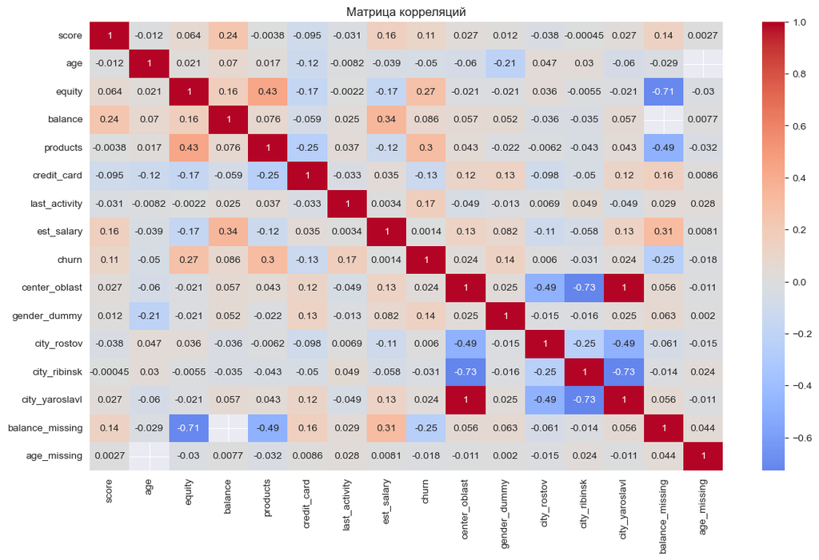

```python
plt.figure(figsize = (14,8))
sns.heatmap(banki_corr.corr(),
            annot = True,
            cmap='coolwarm',
            center = 0,
            )
plt.title('Матрица корреляций')
plt.xlabel('')
plt.ylabel('')
plt.show()
```

Пропущенные данные в столбце "возраст" не скореллированы с другими признаками. Таких пропусков менее 1%, они, скорее всего, возникли из-за технического сбоя и относятся к категории совершенно случайных пропусков (MCAR). Можем их отбросить или заполнить.

```python
balance_missing = banki.pivot_table(index = 'balance_missing',
                                    values = ['equity','products'],
                                    aggfunc = 'median').reset_index()

balance_missing.loc[0,'balance_missing'] = 'есть данные о балансе'
balance_missing.loc[1,'balance_missing'] = 'нет данных о балансе'
balance_missing.columns = ['пропущенные данные', \
                           'количество баллов собственности','количество используемых продуктов']
balance_missing
```

|  | пропущенные данные | количество баллов собственности | количество используемых продуктов |
| --- | --- | --- | --- |
| 0 | есть данные о балансе | 4 | 2 |
| 1 | нет данных о балансе | 0 | 1 |

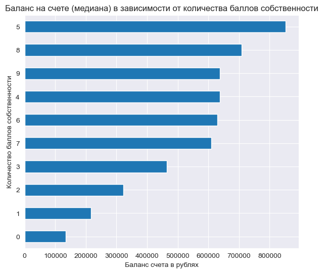

```python
#Посмотрим медианное значение баланса в разрезе по количеству баллов собственности
banki.pivot_table(index = 'equity',
                  values = 'balance',
                  aggfunc = 'median')\
                  .sort_values('balance')\
                  .plot(kind = 'barh',
                        figsize = (7,6),
                        title = 'Баланс на счете (медиана) в зависимости от количества баллов собственности',
                                              legend = False)

plt.ylabel('Количество баллов собственности')
plt.xlabel('Баланс счета в рублях')
plt.show()
```

Медианный баланса счета для клиентов с разным количеством баллов собственности различается.

### Обработка пропусков

Резюме:

Пропуски в поле баланс счета относятся к неслучайным (MNAR). Так как есть корреляция пропусков баланса счета с количеством баллов собственности, а также средний баланс счета заметно различается в зависимости от баллов собственности, *заполним пропуски в поле 'balance' медианным значением для групп по количеству баллов собственности.*

Пропущенные данные в столбце "возраст" не скореллированы с другими признаками, таковых менее 1%, они, скорее всего, возникли из-за технического сбоя и относятся к категории совершенно случайных пропусков (MCAR). Пропуски возраста заполним медианой для групп по количеству баллов собственности(аналогично пропускам баланса счета).

```python
for b in banki['equity'].unique():
    banki.loc[(banki['equity'] == b) & (banki['balance'].isna()), 'balance'] = \
    banki.loc[(banki['equity'] == b), 'balance'].median()
```

```python
for b in banki['equity'].unique():
    banki.loc[(banki['equity'] == b) & (banki['age'].isna()), 'age'] = \
    banki.loc[(banki['equity'] == b), 'age'].median()
```

```python
#проверяем как заполнены пропуски
```

```python
banki.isna().sum()
```

```
userid             0
score              0
age                0
equity             0
balance            0
products           0
credit_card        0
last_activity      0
est_salary         0
churn              0
center_oblast      0
city_str           0
gender_str         0
gender_dummy       0
city_rostov        0
city_ribinsk       0
city_yaroslavl     0
balance_missing    0
age_missing        0
dtype: int64
```

## Проверка аномальных значений

Проверим непрерывные признаки balance и EST_SALARY на наличие аномально-высоких и инизких значений: максимум в этих полях очевидно выбивается.

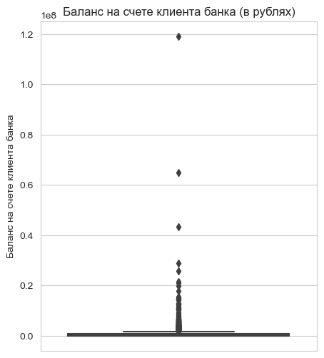

```python
#Посмотрим на аномалии
sns.set_style("whitegrid")
plt.figure(figsize=(5, 6))

ax = sns.boxplot(y="balance", data=banki)
ax.set_title('Баланс на счете клиента банка (в рублях)')
ax.set_ylabel('Баланс на счете клиента банка')
plt.show()
```

Выброс не единичный. Большинство клиентов банка имеют на счету менее 2 млн. рублей. Посмотрим, какова доля значений свыше 2 млн.

```python
b = round(len(banki.query('balance > 2000000')) / len(banki)*100)
print(f'Доля аномально-высоких значений в поле balance - {b}%.')
```

```
Доля аномально-высоких значений в поле balance - 4%.
```

```python
#создадим переменную, обозначающую клиентов с балансом свыше 2 млн
banki['big_balance'] = 0
banki.loc[banki['balance'] > 2000000, 'big_balance'] = 1
#сравним значение целевого показателя в группах с аномальным и нормотипичным балансом на счету
big_balance = banki.pivot_table(index = 'big_balance', values = 'churn',
                                aggfunc = {'mean', 'count'}).reset_index()
big_balance.loc[0, 'big_balance'] = 'типичный баланс счета'
big_balance.loc[1, 'big_balance'] = 'аномально-высокий баланс счета'
big_balance.columns = ['Баланс счета', 'N клиентов', '% оттока']
big_balance
```

|  | Баланс счета | N клиентов | % оттока |
| --- | --- | --- | --- |
| 0 | типичный баланс счета | 9570 | 0.17 |
| 1 | аномально-высокий баланс счета | 428 | 0.49 |

Среди клиентов с аномально-высоким балансом половина - отточные. В целом доля таковых клиентов невысока(4%) и их можно удалить. Посомотрим, как обстоит дело с EST_SALARY, не пересекаются ли аномальные значения этих двух переменных.

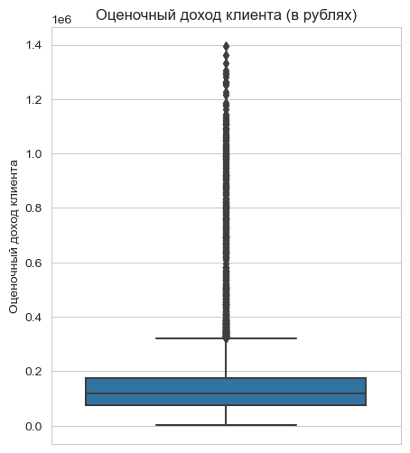

```python
#Посмотрим на аномалии
plt.figure(figsize=(5, 6))
sns.set_style("whitegrid")
ax = sns.boxplot(y="est_salary", data=banki)
ax.set_title('Оценочный доход клиента (в рублях)')
ax.set_ylabel('Оценочный доход клиента')
plt.show()
```

Выброс не единичный. Доход большинства клиентов банка оценен ниже 400 тыс.рублей. Посмотрим, какова доля значений свыше 400 тыс.

```python
s = round(len(banki.query('est_salary > 400000')) / len(banki)*100)
```

```python
print(f'Доля аномально-высоких значений в поле est_salary - {s}%.')
```

```
Доля аномально-высоких значений в поле est_salary - 3%.
```

```python
#создадим переменную, обозначающую клиентов с доходом свыше 400 тыс.
banki['big_salary'] = 0
banki.loc[banki['est_salary'] > 400000, 'big_salary'] = 1
#сравним значение целевого показателя в группах с аномальным и нормотипичным балансом на счету
big_salary= banki.pivot_table(index = 'big_salary', values = 'churn',
                                aggfunc = {'mean', 'count'}).reset_index()
big_salary.loc[0, 'big_salary'] = 'типичный оценочный доход'
big_salary.loc[1, 'big_salary'] = 'аномально-высокий оценочный доход'
big_salary.columns = ['Оценочный доход', 'N клиентов', '% оттока']
big_salary
```

|  | Оценочный доход | N клиентов | % оттока |
| --- | --- | --- | --- |
| 0 | типичный оценочный доход | 9661 | 0.18 |
| 1 | аномально-высокий оценочный доход | 337 | 0.15 |

Средний показатель оттока в двух группах существенно не различается. Посчитаем, какая доля данных приходится на аномальные значения в обоих показателях (balance и est_salary).

```python
a = round(len(banki.query('big_balance == 1 | big_salary == 1'))/len(banki)*100, 1)
print(f'На аномалии по двум показателям приходится {a}% данных')
```

```
На аномалии по двум показателям приходится 6.8% данных
```

Можем отфильтровать аномальные значения, потери составят менее 7% данных. Отфильтрованный массив сохраним под новым именем.

```python
banki_filt = banki.loc[((banki['big_balance'] == 0) & (banki['big_salary'] == 0))]
```

Проверим распределение отфильтрованных переменных

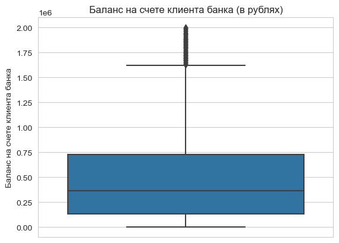

```python
plt.figsize=(5, 5)
sns.set_style("whitegrid")
ax = sns.boxplot(y="balance", data=banki_filt)
ax.set_title('Баланс на счете клиента банка (в рублях)')
ax.set_ylabel('Баланс на счете клиента банка')
None
```

Очевидных выбросов не наблюдается, есть категория клиентов с балансом счета в 4-5 раз выше среднего, это вполне реально.

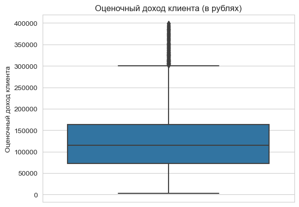

```python
plt.figsize=(5, 5)

ax = sns.boxplot(y="est_salary", data=banki_filt)
ax.set_title('Оценочный доход клиента (в рублях)')
ax.set_ylabel('Оценочный доход клиента')
None
```

Очевидных выбросов не наблюдается, есть категория клиентов с оценочным доходом в 3-4 раза выше среднего, такое допустимо.

```python
diff = round(100-len(banki_filt)/len(banki)*100)
print(f'В результате обработки массива отфильровано {diff}% данных.')
```

```
В результате обработки массива отфильровано 7% данных.
```

## Вывод по предобработке данных

Массив был проверен на предмет пропусков и аномалий, проведена перекодировка категориальных переменных в бинарные, проверены дубликаты.

Удален один дубликат.

В результате проверки на аномалии, баланс счета свыше 2 млн. руб. и доход свыше 400 тыс. руб. отнесены к аномально-высоким значениям для этих признаков; такие значения отфильтрованы.

Пропущенные данные баланса счета кореллируют с количеством баллов собственности(чем ниже бал - тем выше вероятность пропуска значений в переменной balance); также медианное значение баланса счета существенно различается в завсимости от бала собственности. Было решено заполнить пропуски поля balance медианным значением для категорий по полю equity(количество баллов собственности).

В результате обработки массива отфильтровано 7% данных, это допустимые потери.

# Описание сегментов клиентов банка, склонных к оттоку. Исследовательский анализ данных

Задача данной части исследования - изучить характеристики клиентов банка и описать сегменты, склонные к оттоку.

```python
#Посчитаем средний % оттока по банку
banki_filt['churn'].value_counts()/len(banki_filt)
```

```
churn
0   0.83
1   0.17
Name: count, dtype: float64
```

```python
banki_filt['churn'].value_counts()
```

```
churn
0    7726
1    1594
Name: count, dtype: int64
```

## Отток клиентов в зависимости от финансовых показателей: оценочного дохода, баланса счета, баллов кредитного скоринга, пользования кредитными продуктами и кредитными картами, количества баллов собственности

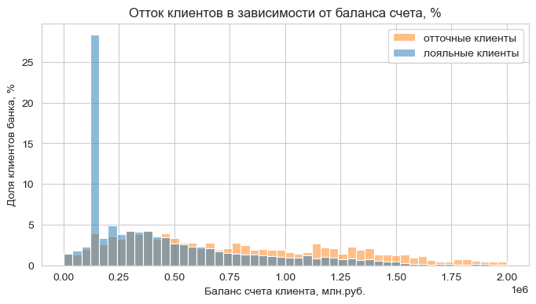

```python
#смотрим отток в зависимости от баланса счета
plt.figure(figsize = (8,4))
ax = sns.histplot(data = banki_filt, x="balance",
                   hue = "churn",
                   stat="percent", common_norm=False,
                  bins = 50
                        )
ax.set_title('Отток клиентов в зависимости от баланса счета, %')
ax.set_ylabel('Доля клиентов банка, %')
ax.set_xlabel('Баланс счета клиента, млн.руб.')
ax.legend(labels = ["отточные клиенты", "лояльные клиенты"])
plt.show()
```

В сегменте с балансом счета до 350 тыс.руб. доля отточных клиентов строго ниже, чем стабильных. С повышением баланса счета карты выше 450 тыс.руб. соотношение между стабильными и отточными клиентами начинает меняться в пользу последних; начиная с баланса 750 тыс.руб. на счете отточных клиентов становится в 2 и более раз больше чем стабильных.

Установим предварительно 3 интервала для сравнения процента оттока клиентов:

- 0 - 349 руб - стабильный сегмент
- 350 - 749 - слабо-отточный сегмент
- 750 и более тыс. руб. - отточный сегмент

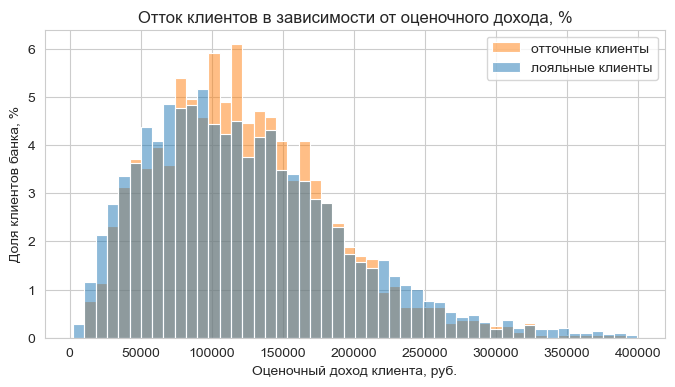

```python
# смотрим отток в зависимости от оценочного дохода
plt.figure(figsize = (8,4))
ax = sns.histplot(data = banki_filt, x="est_salary",
                   hue = "churn",
                   stat="percent",
                   common_norm=False,
                      bins = 50

                        )
ax.set_title('Отток клиентов в зависимости от оценочного дохода, %')
ax.set_ylabel('Доля клиентов банка, %')
ax.set_xlabel('Оценочный доход клиента, руб.')
ax.legend(labels = ["отточные клиенты", "лояльные клиенты"])
plt.show()
```

```python
banki_filt['est_salary'].describe()
```

```
count     9320.00
mean    123685.07
std      68125.29
min       2546.30
25%      72375.36
50%     114320.11
75%     163698.61
max     399043.43
Name: est_salary, dtype: float64
```

Более склонны к оттоку клиенты со оценочным доходом от 70 до 135 тыс.руб. При том, что медианный доход - 114 тыс.руб., а стд.отклонение - 68 тыс., этот интервал характеризует средний доходо клиентов банка.

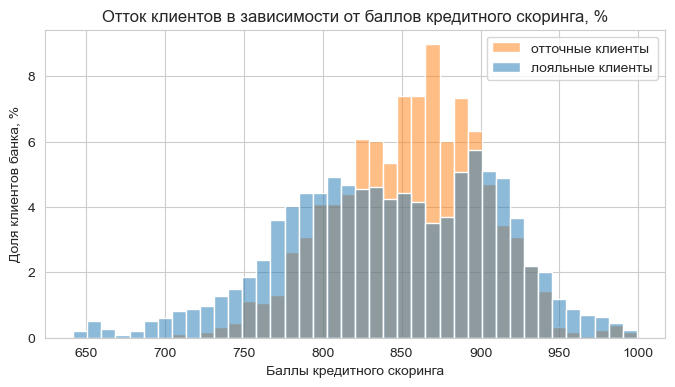

```python
# смотрим отток в зависимости от баллов кредитного скоринга
plt.figure(figsize = (8,4))
ax = sns.histplot(data = banki_filt, x="score",
                   hue = "churn",
                   stat="percent",
                   common_norm=False,
                      bins = 40
                        )
ax.set_title('Отток клиентов в зависимости от баллов кредитного скоринга, %')
ax.set_ylabel('Доля клиентов банка, %')
ax.set_xlabel('Баллы кредитного скоринга')
ax.legend(labels = ["отточные клиенты", "лояльные клиенты"])
plt.show()
```

Отток клиентов с количеством баллов 800-900 - выше, нежели отток клиентов с более низким и более высоким кредитным рейтингом. Снова выделяем три сегмента.

- до 800 баллов - стабильный сегмент(отток стабильно ниже стабильных клтиентов)
- 800 - 900 баллов - высоко-отточный сегмент
- 900 балов и выше - слабоотточны сегмент

Далее посмотрим отток в разрезе по количеству используемых клиентом банковских продуктов и наличию кредитной карты.

```python
products_churn = banki_filt.pivot_table(index = 'products', values = 'churn', aggfunc = {'count','sum'})
```

```python
products_churn.columns = ['N клиентов', 'отток']
products_churn['% клиентов'] = products_churn['N клиентов']/len(banki_filt)*100
products_churn['стабильные'] = products_churn['N клиентов'] - products_churn['отток']
products_churn['% стабильных'] = (products_churn['N клиентов'] \
                                           - products_churn['отток'])/products_churn['N клиентов']*100
products_churn['% оттока'] = products_churn['отток']/products_churn['N клиентов']*100
```

```python
products_churn
```

| products | N клиентов | отток | % клиентов | стабильные | % стабильных | % оттока |
| --- | --- | --- | --- | --- | --- | --- |
| 0 | 1 | 1 | 0.01 | 0 | 0.00 | 100.00 |
| 1 | 3120 | 223 | 33.48 | 2897 | 92.85 | 7.15 |
| 2 | 4833 | 872 | 51.86 | 3961 | 81.96 | 18.04 |
| 3 | 952 | 255 | 10.21 | 697 | 73.21 | 26.79 |
| 4 | 395 | 235 | 4.24 | 160 | 40.51 | 59.49 |
| 5 | 19 | 8 | 0.20 | 11 | 57.89 | 42.11 |

Всего есть 5 банковских продуктов, 85% клиентов используют 1 или 2 продукта, 3-4 продукта - оставшиеся 15%. Ноль продуктов - всего у одного клиента и он уже ушел; исключим его из анализа, чтобы не искажать изображение на графике.

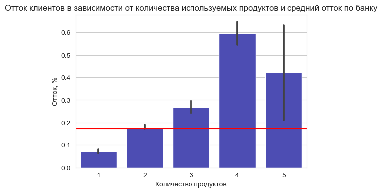

```python
#посмотрим процент оттока в зависимости от количества используемых продуктов
plt.figure(figsize=(6,4))
ax = sns.barplot(data = banki_filt.query('products > 0'), x = 'products',
                 y = 'churn',
#                 errorbar= None,
                color = 'blue',
                saturation=0.4,
                                 )
ax.set_title('Отток клиентов в зависимости от количества используемых продуктов и средний отток по банку')
ax.set_ylabel('Отток, %')
ax.set_xlabel('Количество продуктов')
plt.axhline (y = banki_filt['churn'].mean(), color = 'red')
#ax.bar_label(ax.containers[0], fontsize=10,
#             fmt=lambda x: f'{x * 100:.0f}%'
             #fmt='{:,.2f}')

plt.show()
```

- пользователи 4-5 продуктов - сегмент с сильным оттоком;
- пользователи 3 продуктов - слабо-отточный сегмент; так как это многочисленная (по сравнению с высоко-отточным сегментом) группа, то ее можно объединить с сегментом с сильным оттоком при анализе, либо рассмотреть отдельно;
- пользователи 1-2 продуктов - стабильный сегмент

Посмотрим процент оттока в зависимости от наличия кредитной карты

```python
card_churn = banki_filt['credit_card'].value_counts().reset_index()
card_churn['percent'] = card_churn['credit_card'] / len(banki_filt)*100
card_churn
```

|  | index | credit_card | percent |
| --- | --- | --- | --- |
| 0 | 1 | 6402 | 68.69 |
| 1 | 0 | 2918 | 31.31 |

Более половины (69%) клиентов банка владеют крдеитными картами. Посмотрим процент оттока среди владельцев кредитных карт и тех, кто таковыми не является.

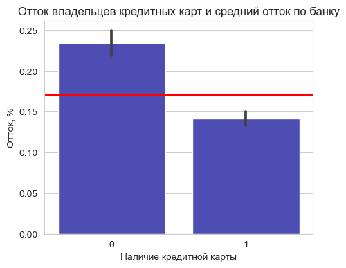

```python
# посмотрим процент оттока для владельцев кредитных карт
plt.figure(figsize=(5,4))
ax = sns.barplot(data = banki_filt, x = 'credit_card', y = 'churn',
                 color = 'blue',
                saturation=0.4,
                )
plt.axhline (y = banki_filt['churn'].mean(), color = 'red')
ax.set(title = 'Отток владельцев кредитных карт и средний отток по банку',
    ylabel = 'Отток, %',
    xlabel = 'Наличие кредитной карты')

plt.show()
```

Треть клиентов банка отказались от кредитной карты, и именно среди них 23% оттока, что выше, чем в среднем по банку. Среди владельцев кредиток, которых в датасете большинство, отток ниже среднего.

Посмотрим на количество баллов собсатвенности.

```python
equity = banki_filt['equity'].value_counts().reset_index()
```

```python
equity['percent'] = equity['equity']/len(banki_filt)*100
equity.columns=['количество баллов', 'N клиентов',  'Процент клиентов']
equity
```

|  | количество баллов | N клиентов | Процент клиентов |
| --- | --- | --- | --- |
| 0 | 0 | 2384 | 25.58 |
| 1 | 5 | 1709 | 18.34 |
| 2 | 4 | 1707 | 18.32 |
| 3 | 3 | 1482 | 15.90 |
| 4 | 2 | 1031 | 11.06 |
| 5 | 1 | 758 | 8.13 |
| 6 | 6 | 146 | 1.57 |
| 7 | 7 | 75 | 0.80 |
| 8 | 8 | 15 | 0.16 |
| 9 | 9 | 13 | 0.14 |

Более половины клиентов банка имеют 3-5 баллов. У 25% - ноль баллов, 6 и более баллов имеют менее 5% клиентов.

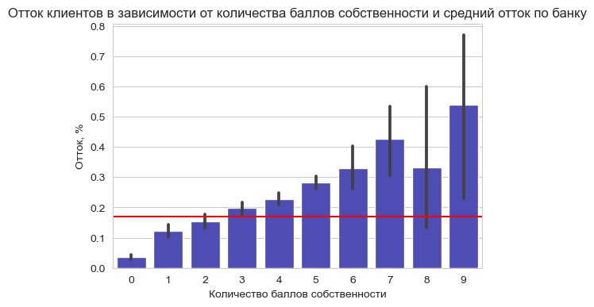

```python
#посмотрим процент оттока в зависимости от количества баллов собственности
plt.figure(figsize=(6,4))
ax = sns.barplot(data = banki_filt, x = 'equity', y = 'churn',
                 color = 'blue',
                saturation=0.4,
                )
plt.axhline (y = banki_filt['churn'].mean(), color = 'red')
ax.set_title('Отток клиентов в зависимости от количества баллов собственности и средний отток по банку')
ax.set_ylabel('Отток, %')
ax.set_xlabel('Количество баллов собственности')
plt.show()
```

Чем больше баллов собственности - тем выше процент оттока. Учитывая, что 3+ баллов собственности в сумме имеют 55% клиентов банка, этот сегмент можно считать высоко-отточным.

## Отток клиентов в зависимости от расположения филиала банка

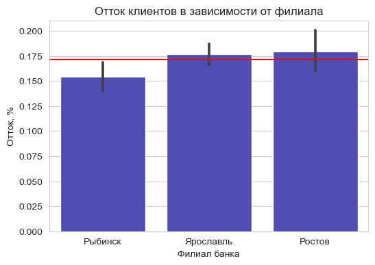

```python
plt.figure(figsize=(6,4))
ax = sns.barplot(data = banki_filt, x = 'city_str', y = 'churn',
                color = 'blue',
                saturation=0.4,
                )
plt.axhline (y = banki_filt['churn'].mean(), color = 'red')
ax.set(title = 'Отток клиентов в зависимости от филиала',
    ylabel = 'Отток, %',
    xlabel = 'Филиал банка')
plt.show()
```

Во всех филиалах процент оттока незначительно отличается от среднего. Среди клиентов Рыбинска отток несколько ниже, чем в других филиалах. Посмотрим, есть ли разница между отделениями в центре и областных городах

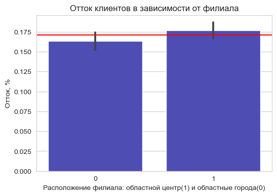

```python
plt.figure(figsize=(6,4))
ax = sns.barplot(data = banki_filt, x = 'center_oblast', y = 'churn',
                color = 'blue',
                saturation=0.4,
                )
plt.axhline (y = banki_filt['churn'].mean(), color = 'red')
ax.set(title = 'Отток клиентов в зависимости от филиала',
    ylabel = 'Отток, %',
    xlabel = 'Расположение филиала: областной центр(1) и областные города(0)')
plt.show()
```

```python
center_oblast_churn = banki_filt['center_oblast'].value_counts().reset_index()
center_oblast_churn['percent'] = center_oblast_churn['center_oblast']/len(banki_filt)*100
center_oblast_churn
```

|  | index | center_oblast | percent |
| --- | --- | --- | --- |
| 0 | 1 | 5390 | 57.83 |
| 1 | 0 | 3930 | 42.17 |

На филиалы банка в областном центре приходится более половины клиентов и здесь отток несколько выше, нежели в филиалах в областных городах. Однако относительная разница в оттоке - 2пп.; географический фактор не может считаться значимым фактором оттока клиентов.

## Отток клиентов в зависимости от социально-демографических характеристик

Могут ли пол и возраст влиять на отток клиента?

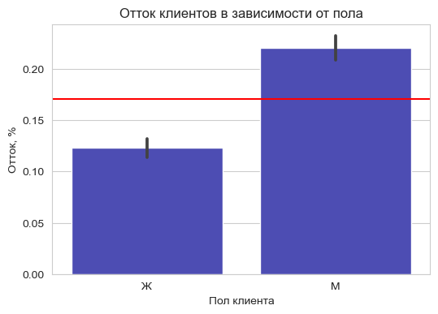

```python
plt.figure(figsize=(6,4))
ax = sns.barplot(data = banki_filt, x = 'gender_str', y = 'churn',
                color = 'blue',
                saturation=0.4,
                )
plt.axhline (y = banki_filt['churn'].mean(), color = 'red')
ax.set(title = 'Отток клиентов в зависимости от пола',
    ylabel = 'Отток, %',
    xlabel = 'Пол клиента')
plt.show()
```

Мужчины и женщины в датасете представлены практически в равных пропорциях, среди последних уровень оттока выше среднего по банку и выше чем среди женщин.

```python
banki_filt['age'].describe()
```

```
count   9320.00
mean      42.62
std       12.22
min       18.00
25%       33.00
50%       40.00
75%       51.00
max       86.00
Name: age, dtype: float64
```

Диапазон возраста клиентов - от 18 до 86 лет, средний возраст - 42,5 года.

[figure not shown]

```python
# смотрим отток в зависимости от возраста
plt.figure(figsize = (8,4))
ax = sns.histplot(data = banki_filt, x="age",
                   hue = "churn",
                   stat="percent",
                   common_norm=False,
                      bins = 50
                 )
ax.set_title('Отток клиентов в зависимости от возраста, %')
ax.set_ylabel('Доля клиентов банка, %')
ax.set_xlabel('Возраст')
ax.legend(labels = ["отточные клиенты", "лояльные клиенты"])
plt.show()
```

Склонными к оттоку можно считать 2 возрастных сегмента:

- молодежь - 24-35 лет (молодежью считаются люди до 35 лет)
- клиенты предпенсионного возраста - 50-60 лет

## Распределение клиентов по полу и возрасту

Так наблюдается разница в оттоке для мужчин и женщин, а также в разрезе возрастных групп, имеет смысл посмотреть распределение М и Ж по возрасту.

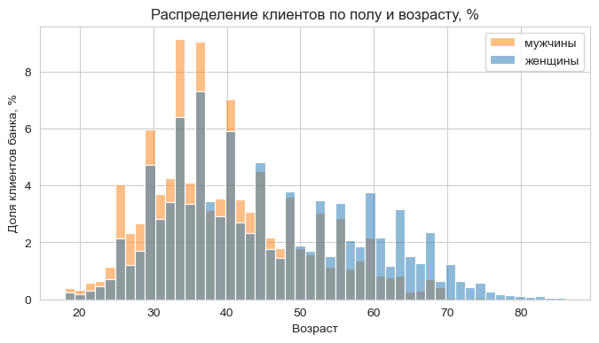

```python
# распределение М и Ж в зависимости от возраста

plt.figure(figsize = (8,4))
ax = sns.histplot(data = banki_filt, x="age",
                   hue = "gender_str",
                   stat="percent",
                   common_norm=False,
                      bins = 50
                 )
ax.set_title('Распределение клиентов по полу и возрасту, %')
ax.set_ylabel('Доля клиентов банка, %')
ax.set_xlabel('Возраст')
ax.legend(labels = ["мужчины", "женщины"])
plt.show()
```

Средний возраст клиентов банка мужского пола ниже среднего возраста женщин; среди клиентов до 50 лет преобладают мужчины, среди клиентов старше 50 - женщины; жто может объясняться более низкой продолжительностью жизни мужчин в РФ.

## Анализ корреляции признаков

```python
#сформируем датасет без строковых переменных и служебных переменных для матрицы корреляций признаков
banki_filt_corr = banki_filt.drop(['userid','city_str', 'gender_str', 'big_salary', 'big_balance', 'balance_missing', 'age_missing'], axis = 1)
```

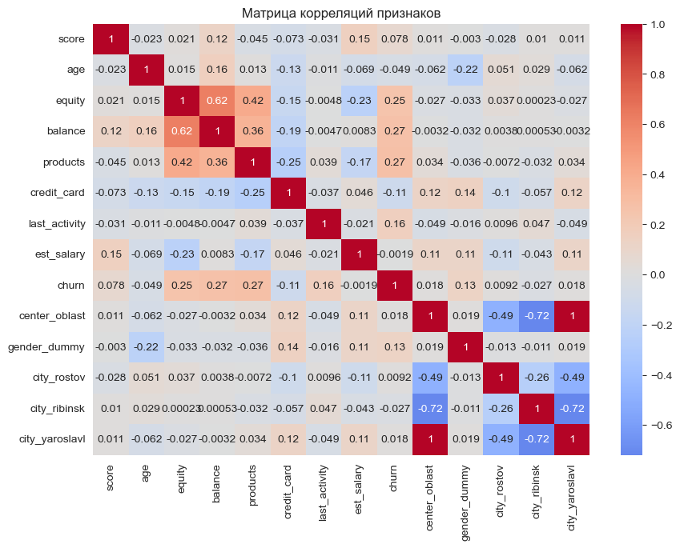

```python
plt.figure(figsize = (10,7))
sns.heatmap(banki_filt_corr.corr(),
            annot = True,
            cmap='coolwarm',
            center = 0,
            )
plt.title('Матрица корреляций признаков')
plt.xlabel('')
plt.ylabel('')
plt.show()
```

Об умеренной (0,3-0,5) или заметной (0,5-0,7) связи можно говорить только в отношении характеристик финансового поведения клиентов банка:

- наблюдается заметная положительная связь между балансом счета и количеством баллов собственности;
- умеренная положительная связь между балансом счета и количеством используемых продуктов;
- умеренная положительная связь количества используемых продуктов с количеством баллов собственности

Корреляция целевого показателя оттока с этими переменными слабая(коэффициент корреляции в диапазоне 0,1-0,3).

## Портрет клиента банка в разрезе оттока

Сравним отточных и стабильных клиентов банка по социально-демографическим характеристикам и признакам, описывающим их финансовое поведение. Для начала посчитаем характеристики в разрезе оттока, затем сформируем таблицу, описывающую две совокупности. Для бинарных и категориальных незакодированных признаков будем рассчитывать моду, для категориальных небинарных - медиану, для непрерывных - среднее значение.

```python
churn_city_mode = statistics.mode(banki.query('churn == 1')['city_str'])
notchurn_city_mode = statistics.mode(banki.query('churn == 0')['city_str'])
print(f'Среди отточных клиентов основной филиал {churn_city_mode}, среди неотточных - {notchurn_city_mode}')
```

```
Среди отточных клиентов основной филиал Ярославль, среди неотточных - Ярославль
```

```python
churn_gender_mode = statistics.mode(banki.query('churn == 1')['gender_str'])
notchurn_gender_mode = statistics.mode(banki.query('churn == 0')['gender_str'])
print(f'Среди отточных клиентов преобладают {churn_gender_mode}, среди неотточных - {notchurn_gender_mode}')
```

```
Среди отточных клиентов преобладают М, среди неотточных - Ж
```

```python
churn_age_mean = round(statistics.mean(banki.query('churn == 1')['age']))
notchurn_age_mean = round(statistics.mean(banki.query('churn == 0')['age']))
print(f'Средний возраст отточных клиентов {churn_age_mean},  неотточных - {notchurn_age_mean}')
```

```
Средний возраст отточных клиентов 41,  неотточных - 43
```

```python
churn_score_mean = round(statistics.mean(banki.query('churn == 1')['score']))
notchurn_score_mean = round(statistics.mean(banki.query('churn == 0')['score']))
print(f'Средний кредитный рейтинг отточных клитентов  {churn_score_mean},  неотточных - {notchurn_score_mean}')
```

```
Средний кредитный рейтинг отточных клитентов  863,  неотточных - 845
```

```python
churn_balance_mean = round(statistics.mean(banki.query('churn == 1')['balance']))
notchurn_balance_mean = round(statistics.mean(banki.query('churn == 0')['balance']))
print(f'Средний баланс счета отточных клиентов {churn_balance_mean},  неотточных - {notchurn_balance_mean}')
```

```
Средний баланс счета отточных клиентов 1127030,  неотточных - 567799
```

```python
churn_balance_median = round(statistics.median(banki.query('churn == 1')['balance']))
notchurn_balance_median = round(statistics.median(banki.query('churn == 0')['balance']))
print(f'Медианный баланс счета отточных клиентов {churn_balance_median},  неотточных - {notchurn_balance_median}')
```

```
Медианный баланс счета отточных клиентов 775349,  неотточных - 320860
```

```python
churn_salary_mean = round(statistics.mean(banki.query('churn == 1')['est_salary']))
notchurn_salary_mean = round(statistics.mean(banki.query('churn == 0')['est_salary']))
print(f'Средний оценочный доход отточных клиентов {churn_salary_mean},  неотточных - {notchurn_salary_mean}')
```

```
Средний оценочный доход отточных клиентов 148243,  неотточных - 147726
```

```python
churn_salary_median = round(statistics.median(banki.query('churn == 1')['est_salary']))
notchurn_salary_median = round(statistics.median(banki.query('churn == 0')['est_salary']))
print(f'Медианный оценочный доход отточных клиентов {churn_salary_median},  неотточных - {notchurn_salary_median}')
```

```
Медианный оценочный доход отточных клиентов 125391,  неотточных - 118249
```

```python
churn_equity_median = statistics.median(banki.query('churn == 1')['equity'])
notchurn_equity_median = statistics.median(banki.query('churn == 0')['equity'])
print(f'Среднее число баллов собственности отточных клиентов {churn_equity_median},  неотточных - {notchurn_equity_median}')
```

```
Среднее число баллов собственности отточных клиентов 4.0,  неотточных - 3.0
```

```python
сhurn_products_median = statistics.median(banki.query('churn == 1')['products'])
notchurn_products_median = statistics.median(banki.query('churn == 0')['products'])
print(f'Среднее число банковских продуктов у отточных клиентов {сhurn_products_median},  неотточных - {notchurn_products_median}')
```

```
Среднее число банковских продуктов у отточных клиентов 2.0,  неотточных - 2.0
```

```python
churn_card_mode = statistics.mode(banki.query('churn == 1')['credit_card'])
notchurn_card_mode = statistics.mode(banki.query('churn == 0')['credit_card'])
print(f'Среди отточных клиентов модальное значение владельцев кредитных карт {churn_card_mode}, среди неотточных - {notchurn_card_mode}')
```

```
Среди отточных клиентов модальное значение владельцев кредитных карт 1, среди неотточных - 1
```

Обобщим результаты в таблицу; для средних показателей (доход, баланс счета, кредитный рейтинг) посчитаем относительную разницу отточного показателя к неотточному в %.

```python
salary_diff = round((churn_salary_mean - notchurn_salary_mean)/churn_salary_mean*100,1)
balance_diff = round((churn_balance_mean - notchurn_balance_mean)/churn_balance_mean*100,1)
score_diff = round((churn_score_mean - notchurn_score_mean)/churn_score_mean*100,1)
```

```python
print(f'Относительная разница отточного показателя по отношению к неотточному\
        для среднего дохода - {salary_diff}%, \
        для баланса счета - {balance_diff}%, \
        для кредитного скоринга - {score_diff}%.'
     )
```

```
Относительная разница отточного показателя по отношению к неотточному        для среднего дохода - 0.3%,         для баланса счета - 49.6%,         для кредитного скоринга - 2.1%.
```

```python
features = ['Пол(мода)', 'Средний возраст', 'Филиал банка(мода)', "Средний оценочный доход", "Медианный доход",
            "Средний баланс счета", "Медианный баланс счета", "Количество баллов собственности(медиана)",
           "Количество банковских продуктов(медиана)", "Наличие кредитной карты",
           "Средний балл кредитного скоринга"]

churn_features = [churn_gender_mode, churn_age_mean, churn_city_mode, churn_salary_mean, churn_salary_median,\
                  churn_balance_mean,churn_balance_median, churn_equity_median,\
                 сhurn_products_median, churn_card_mode, churn_score_mean]

notchurn_features = [notchurn_gender_mode, notchurn_age_mean, notchurn_city_mode, notchurn_salary_mean,\
                  notchurn_salary_median, notchurn_balance_mean, notchurn_balance_median, notchurn_equity_median,\
                     notchurn_products_median, notchurn_card_mode, notchurn_score_mean]

diff = [' ',' ',' ', salary_diff,' ',balance_diff,' ',' ',' ',' ',score_diff]

client_portret = pd.DataFrame({'Признак': features,
            'Отток': churn_features,
              'Не отток': notchurn_features,
                'Относительная разница, %': diff
                              }

            )
```

```python
client_portret
```

|  | Признак | Отток | Не отток | Относительная разница, % |
| --- | --- | --- | --- | --- |
| 0 | Пол(мода) | М | Ж |  |
| 1 | Средний возраст | 41 | 43 |  |
| 2 | Филиал банка(мода) | Ярославль | Ярославль |  |
| 3 | Средний оценочный доход | 148243 | 147726 | 0.30 |
| 4 | Медианный доход | 125391 | 118249 |  |
| 5 | Средний баланс счета | 1127030 | 567799 | 49.60 |
| 6 | Медианный баланс счета | 775349 | 320860 |  |
| 7 | Количество баллов собственности(медиана) | 4.00 | 3.00 |  |
| 8 | Количество банковских продуктов(медиана) | 2.00 | 2.00 |  |
| 9 | Наличие кредитной карты | 1 | 1 |  |
| 10 | Средний балл кредитного скоринга | 863 | 845 | 2.10 |

В таблице группы отточных и неотточных клиентов описаны средними показателями; средние меры не во всех случаях позволяют дифференциировать отточных клиентов, выраженная разница наблюдается только по полу, а также по среднему балансу счета. Для уточнения дифференциируюющих отточных и неотточных клиентов показателей используем данные таблицы и графиков.

## Выводы

1. Средняя доля оттока по банку - 17%

2. Отток клиентов выше среднего наблюдается для следюущих групп:

2.1 **Пол:** среди мужчин отток 23%, среди женщин - ниже среднего.

2.2 **Средний возраст** не значительно дифференциирует отточных и неотточных клиентов; однако есть два возрастных сегмента, которые могут быть более склонны к оттоку: - молодежь - 24-35 лет (молодежью считаются люди до 35 лет) - клиенты предпенсионного возраста - 50-60 лет; так как в РФ пенсионный возраст мужчины - 63 года, логичным будет установить верхнюю границу интервала предпенсионного возраста 63; Важно, что среди клиентов до 50 лет мужчины, которые более склонны к оттоку, преобладают, поэтому вклад пола и возраста в отток можно рассматривать в совокупности.

2.3 **Баланс счета и собственность** клиенты с бОльшим числом накоплений - у них выше баланс счета и больше баллов собственности: - баланс счета 750 и более тыс. руб. - отточный сегмент; - в группе с тремя и более баллами собственности (на которую приходится половина клиентов) - отток от 20 до 54%.

2.4 **Доход**: разницу в доходе между отточными и неотточными клиентами нельзя назвать выраженной (как по медианному, так и по среднему показателю), гипотеза о том, что клиенты с более высоким доходом чаще уходят из банка - нуждается в проверке:

```
 - есть вероятность, что более склонны к оттоку клиенты со средним оценочным доходом от 70 до 135 тыс.руб., нежели клиенты с более низким или более высоким доходом. Также необходимо проверить % оттока для интервала 70-165 тыс. руб.
```

2.5 **Продукты банка**: чем больше продуктов использует клиент, тем выше % оттока:

```
- пользователи 4-5 продуктов - сегмент с сильным оттоком(более 50%), однако таковых менее 5% клиентов;
- среди пользователи 3 продуктов - отток 27%; таковых 10% клиентов, поэтому группу можно либо объединить с сегментом с сильным оттоком(4-5 продуктов) при анализе, либо рассмотреть отдельно.
```

2.6 **Скоринг:** средний балл скоринга в отточной группе немного выше по сравнению с неотточной, однако наблюдается более высокий отток в группе с 800 - 900 баллами; этот сегмент может быть склонен к оттоку.

2.6 **Наличие кредитки:** клиенты без кредитных карт: треть клиентов банка отказались от кредитной карты, и именно среди них 23% оттока, что выше, чем в среднем по банку. Среди владельцев кредиток, которых в датасете большинство, отток ниже среднего.

# Проверка статистических гипотез

## Выбор гипотез и тестов -1

На первом шаге проверим гипотезы о равенстве *среднего баланса счета* и *среднего дохода* в группах отточных и лояльных клиентов. Также проверим гипотезу о *равенстве среднего возраста отточных и лояльных клиентов допенсионного возраста*.

**Баланс счета и доход - выбросы**

На этапе предобработки данных в переменных баланс счета и доход были удалены явные аномалии, однако выбросы в данных остались и по диаграммам размаха, что таковых значений достаточно много, чтобы внести искажение в тест.

Для проверки гипотез о равенстве среднего дохода и баланса счета у отточных и лояльных клиентов используем непараметрический тест Манна-Уитни

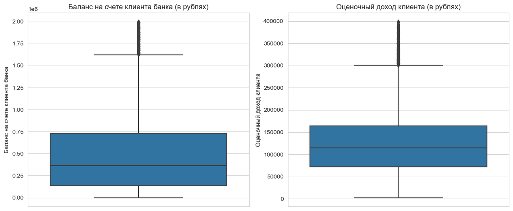

```python
#Распределения признаков баланс счета и оценочный доход
plt.figure(figsize=(12, 5))


ax1 = plt.subplot(1,2,1)
ax1 = sns.boxplot(y="balance", data=banki_filt)
ax1.set_title('Баланс на счете клиента банка (в рублях)')
ax1.set_ylabel('Баланс на счете клиента банка')
#ax1.set_xlabel('Баланс счета в рублях')

ax2 = plt.subplot(1,2,2)
ax2 = sns.boxplot(y="est_salary", data=banki_filt)
ax2.set_title('Оценочный доход клиента (в рублях)')
ax2.set_ylabel('Оценочный доход клиента')

plt.tight_layout()
plt.show()
```

**Возраст - выбросы**

Диаграмма размаха по переменной возраст также показывает выбросы, однако их количество менее 0,5% и эти значения не являются аномальным возрастом, это клиенты в возрасте 78 - 86 лет, такое может быть. К тому же, мы проверяем гипотезу для возрастной группы 63 лет (допенсионный возраст), поэтому выбросы не попадут в выборку.

Для проверки гипотезы о равенстве среднего возраста отточных и лояльных клиентов используем односторонний t-test (альтернативная гипотеза - о том, что проверяемый признак в первой(отточной) совокупности выше, чем во второй(лояльной)). Отточные и лояльные клиенты - две независимые выборки, проводим t-test для двух независимых выборок.

Используем параметр "equal_var=False" - так как совокупности различаются по размеру и, вероятнтно, по набору значимых параметров.

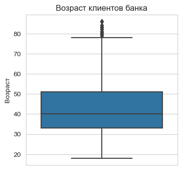

```python
#Распределения признака возраст
plt.figure(figsize=(4, 4))

ax = sns.boxplot(y="age", data=banki_filt)
ax.set_title('Возраст клиентов банка')
ax.set_ylabel('Возраст')
plt.show()
```

```python
len(banki_filt[banki_filt['age'] > 79])/len(banki_filt)*100
```

```
0.20386266094420602
```

## Выбор гипотез и тестов - 2

На втором шаге проверим гипотезы о *равенстве оттока среди мужчин и женщин*; *среди пользователей 1-2 и в группе кто использует 3 и более банковских продукта*. Для этого мы используем тест на сравнение пропорций в двух генеральных совокупностях.

## Проверка гипотезы о равенстве среднего баланса счета у отточных и лояльных клиентов

Гипотеза 1:

```
H0: средний баланс счета в группе отточных и лояльных клиентов одинаков
H1: средний баланс счета в группе отточных и лояльных клиентов различается
```

```python
sample1_churn = banki_filt.query('churn == 1')['balance']
sample2_notchurn = banki_filt.query('churn == 0')['balance']

alpha = 0.05  # критический уровень статистической значимости

results = st.mannwhitneyu(sample1_churn, sample2_notchurn)

print('p-значение: ', results.pvalue)

if results.pvalue < alpha:
    print('Отвергаем нулевую гипотезу, средний баланс счета в группе отточных и лояльных клиентов различается')
else:
    print(
        'Нет оснований отвергнуть нулевую гипотезу, нет значимой разницы среднего баланса счета для отточных и лояльных клиентов'
    )
```

```
p-значение:  1.6726172163651018e-138
Отвергаем нулевую гипотезу, средний баланс счета в группе отточных и лояльных клиентов различается
```

## Проверка гипотезы о равенстве среднего дохода у отточных и лояльных клиентов

Гипотеза 2:

```
H0: средний доход в группе отточных и лояльных клиентов одинаков
H1: средний доход в группе отточных и лояльных клиентов значимо различается
```

```python
sample3_churn = banki_filt.query('churn == 1')['est_salary']
sample4_notchurn = banki_filt.query('churn == 0')['est_salary']

alpha = 0.05  # критический уровень статистической значимости

results = st.mannwhitneyu(sample3_churn, sample4_notchurn)

print('p-значение: ', results.pvalue)

if results.pvalue < alpha:
    print('Отвергаем нулевую гипотезу, средний доход в группе отточных и лояльных клиентов различается')
else:
    print(
        'Нет оснований отвергнуть нулевую гипотезу, нет значимой разницы среднего дохода для отточных и лояльных клиентов'
    )
```

```
p-значение:  0.2535819175168551
Нет оснований отвергнуть нулевую гипотезу, нет значимой разницы среднего дохода для отточных и лояльных клиентов
```

Нет статистически значимой разницы в доходах лояльных и отточных клиентов. При этом, тест подтверждает, что у отточных клиентов баланс счета в среднем выше, чем у лояльных.

## Проверка гипотезы о равенстве оттока среди мужчин и женщин

```
Гипотеза 3:
H0: Отток среди мужчин равен оттоку среди женщин.
H1: Отток среди мужчин отличается от оттока среди женщин.
```

```python
#Посчитаем необходимые значения для сравнения:
n_m = len(banki_filt.query('gender_dummy == 1')) #Количество мужчин в выборке
n_f = len (banki_filt.query('gender_dummy == 0')) # Количество женщин в выборке
churn_m =banki_filt.query('gender_dummy ==1')['churn'].sum() # Количество мужчин, которые ушли
churn_f = banki_filt.query('gender_dummy ==0')['churn'].sum() # Количество женщин, которые ушли
```

```python
successes = np.array([churn_m, churn_f]) # Запишем количество мужчин и женщин, отказавшихся от услуг банка
trials = np.array([n_m, n_f]) # Запишем количество мужчин и женщин в выборке

alpha = .05 # критический уровень статистической значимости

# пропорция успехов в первой группе:
p1 = successes[0]/trials[0]

# пропорция успехов во второй группе:
p2 = successes[1]/trials[1]

# пропорция успехов в комбинированном датасете:
p_combined = (successes[0] + successes[1]) / (trials[0] + trials[1])

# разница пропорций в датасетах
difference = p1 - p2

# считаем статистику в ст.отклонениях стандартного нормального распределения
z_value = difference / mth.sqrt(p_combined * (1 - p_combined) * (1/trials[0] + 1/trials[1]))

# задаем стандартное нормальное распределение (среднее 0, ст.отклонение 1)
distr = st.norm(0, 1)

p_value = (1 - distr.cdf(abs(z_value))) * 2

print('p-значение: ', p_value)

if p_value < alpha:
    print('Отвергаем нулевую гипотезу: доли отточных клиентов среди мужчин и женщин значимо различаются')
else:
    print(
        'Не получилось отвергнуть нулевую гипотезу, нет оснований считать доли отточных клиентов среди мужчин и женщин разными'
    )
```

```
p-значение:  0.0
Отвергаем нулевую гипотезу: доли отточных клиентов среди мужчин и женщин значимо различаются
```

## Проверка гипотезы о равенстве оттока среди клиентов с разным количеством банковских продуктов

Гипотеза 4:

```
H0: Отток среди пользователей 3-5  банковских продуктов равен оттоку среди пользователей 1-2 продуктов.
H1: Отток среди пользователей 3-5  банковских продуктов выше оттока среди пользователей 1-2 продуктов.
```

```python
#Посчитаем необходимые значения для сравнения:
n_1 = len(banki_filt.query('products >= 3'))  #количество наблюдений в группе с 3-5 продуктами
n_2 = len(banki_filt.query('products <3'))  #количество наблюдений в группе с 1-2 продуктами
churn_1 =banki_filt.query('products >= 3')['churn'].sum()  # отток в  группе с 3-5 продуктами
churn_2 = banki_filt.query('products <3')['churn'].sum() # отток в группе с 1-2 продуктами
```

```python
successes = np.array([churn_1, churn_2]) # Запишем количество  отказавшихся от услуг банка в двух группах
trials = np.array([n_1, n_2]) # Запишем количество наблюдений в двух группах

alpha = .05 # критический уровень статистической значимости

# пропорция успехов в первой группе:
p1 = successes[0]/trials[0]

# пропорция успехов во второй группе:
p2 = successes[1]/trials[1]

# пропорция успехов в комбинированном датасете:
p_combined = (successes[0] + successes[1]) / (trials[0] + trials[1])

# разница пропорций в датасетах
difference = p1 - p2

# считаем статистику в ст.отклонениях стандартного нормального распределения
z_value = difference / mth.sqrt(p_combined * (1 - p_combined) * (1/trials[0] + 1/trials[1]))

# задаем стандартное нормальное распределение (среднее 0, ст.отклонение 1)
distr = st.norm(0, 1)

p_value = (1 - distr.cdf(abs(z_value))) * 2

print('p-значение: ', p_value)

if p_value < alpha:
    print('Отвергаем нулевую гипотезу: есть значимая разница оттока для клиентов, использующих 1-2 и 3 и более банковских продуктов')
else:
    print(
        'Не получилось отвергнуть нулевую гипотезу, нет оснований считать доли оттока в кгруппах с различным количеством продуктов разными'
    )
```

```
p-значение:  0.0
Отвергаем нулевую гипотезу: есть значимая разница оттока для клиентов, использующих 1-2 и 3 и более банковских продуктов
```

## Проверка гипотезы о равенстве среднего возраста отточных и лояльных клиентов среди клиентов допенсионного возраста (до 63 лет)

Гипотеза 5:

```
H0: средний возраст отточных и лояльных клиентов допенсионного возраста(до 63 лет) одинаков
H1: средний возраст в группе отточных клиентов выше, чем в группе лояльных клиентов допенсионного возраста(до 63 лет)
```

```python
#сформируем выборки для проверки
sample1_churn = banki_filt.query('churn == 1 & age <= 63')['age']
sample2_notchurn = banki_filt.query('churn == 0 & age <=63')['age']

alpha = 0.05

# проводим ttest для двух совокупностей, в качестве альтернативной используем одностороннюю гипотезу «больше»
results = st.ttest_ind(sample1_churn, sample2_notchurn, alternative='greater', equal_var = False)

print(f'p-value: {results.pvalue}')

# проверяем p-value
if results.pvalue < alpha:
    print('Отвергаем нулевую гипотезу, средний возраст отточных клиентов выше, чем  у лояльных в группе до 63 лет')
else:
    print('Нет оснований отвергнуть нулевую гипотезу, средний возраст отточных клиентов равен возрасту лояльных в группе до 63 лет')
```

```
p-value: 0.24509851608688732
Нет оснований отвергнуть нулевую гипотезу, средний возраст отточных клиентов равен возрасту лояльных в группе до 63 лет
```

## Вывод

Результаты статистических тестов позволяют подтвердить следюущие различия:

- есть значимая разница оттока для мужчин и женщин
- среди клиентов допенсионного (до 63 лет) возраста средний возраст отточных и лояльных клиентов значимо не различается
- есть значимая разница оттока для пользователей большого(3-5) и малого(1-2) количества банковских продуктов
- баланс счета отточных клиентов в среднем выше баланса счета лояльных клиентов
- нет значимой разницы в доходах отточных и лояльных клиентов

# Сегментация отточных клиентов банка

За основание сегментации будут взяты показатели, по которым наблюдается наиболее выраженная дифференциация клиентов, а также подтверждена статистически-значимая разница. Сначала опишем сегменты, потом посчитаем характеризующие их показатели.

**Сегмент 1.** Клиенты с объемом сбережений выше среднего: клиенты с балансом счета выше 750 тыс. руб и тремя и более баллами собственности. Вероятно, эти клиенты либо не уверены в Банке и опасаются за свои накопления, либо ищут для себя более выгодные условия: более высокие ставки по вкладам, привилегии обслуживания при балансе счета свыше Х (такие как проход в бизнес зал в аэропорту, бесплатное обслуживание годовой карты и проч.), либо - ищут возможности инвестирования и хотят совмещать вклады и инвест-стратегии (так как мы не знаем, есть ли в Метанпромбанке инвест-продукты, то однозначно сложно сказать).

**Сегмент 2.** Опытные пользователи банковских продуктов: владельцы кредитных карт и пользователи 3 и более банковских продуктов. Вероятно, эти клиенты отличаются финансовой грамотностью, анализируют и сравнивают продукты между собой, а также с продуктами других банков, и возможно их не устраивают условия обслуживания продуктов. Так как из всех продуктов банка мы знаем только о кредитных картах, рекомендации будут касаться условий обслуживания кредитных карт.

**Сегмент 3.** Клиенты на этапе развития карьеры и роста заработков (25-45 лет) - эта соц-дем категория преобладает среди клиентов банка. Вероятно, у них в банке зарплатные карты. По каким-то причинам часть данной категории не хочет пользоваться услугами банка. В качестве второго признака данного сегмента проверим скоринг: интервал 800-900 баллов достаточно многочисленный в выборке и его можно считать склонным к оттоку.

**Сегмент 4.** Мужчины предпенсионного возраста 50-63 года, платежеспособные, то есть с доходом выше 75 000 (у нас выделился потенциально отточный сегмент с доходом 75-165 тыс руб; при медианном доходе клиентов банка в 114 тыс. этот интервал как раз можно считать средним).

```python
#Считаем количество наблюдений в сегменте и процент оттока


#описываем условие выделения сегментов
condition = [
    ['1. Клиенты со сбережениями выше среднего', 'balance > 750000 & equity >= 3'],
    ['2. Опытные пользователи банковских продуктов','credit_card == 1 & products >= 3'],
    ['3. Клиенты на этапе развития карьеры и роста заработка', '25 <= age <= 45 and 800 <= score <= 900'],
    ['4. Мужчины предпенсионного возраста 50-60 лет, платежеспособные, с доходом выше 75 тыс.руб.', 'gender_dummy == 1 & 50 <= age <= 63 &  est_salary > 75000'],

 ]

# кодируем название массива для удобства
df = banki_filt

for c in condition:
    for elem in c:

        a = len(df.query(c[1])) #численность сегмента
        b = df.query(c[1])['churn'].sum() #количество отточных клиентов
        p = round(b/a*100) #процент оттока

    print()
    print(f'{c[0]}: численность - {a}, отток - {b}, процент оттока -  {p}%')
    print()
```

```
1. Клиенты со сбережениями выше среднего: численность - 2052, отток - 670, процент оттока -  33%


2. Опытные пользователи банковских продуктов: численность - 637, отток - 286, процент оттока -  45%


3. Клиенты на этапе развития карьеры и роста заработка: численность - 3141, отток - 707, процент оттока -  23%


4. Мужчины предпенсионного возраста 50-60 лет, платежеспособные, с доходом выше 75 тыс.руб.: численность - 543, отток - 153, процент оттока -  28%
```

Во всех выделенных сегментах процент оттока выше среднего по банку (17%). Сформулируем рекомендации для каждого из сегментов, сегменты приоритизируем.

# Рекомендации

Сегменты представлены в порядке приорита для отдела маркетинга Банка.

**Сегмент 1.** Клиенты на этапе развития карьеры и роста заработка(25-45 лет): численность - 3141, отток - 707, процент оттока - 23%. Используют, преимущественно, 2 (57%) или 1(27%) продуктов Банка. Вероятно - это дебетовая карта + накопительный счет или потребительский кредит.

Сегмент поставлен на первое место, так как он наиболее многочисленный, и - в определнном смысле - наименее специфичный, а значит - может быть привлечен разными способами. Это люди в активном трудоспособном возрасте, строящие карьеру. Также это люди с достаточно выским кредитным скорингом (800-900 баллов из 1000), то есть - потенциальные и перспективные пользователи ипотеки и потребительских кредитов. Вероятно, в Метанпромбанке оформлена их зарплатная карта, или же основная дебетовая карта для текущих расходов.

**Рекомендация:**

(1) Сформулировать стратегию(стратегии) долгосрочных накоплений и регулярно информировать клиентов: что сделать сейчас, чтобы получить прибавку к пенсии через 20-30 лет / накопить на первый взнос на ипотеку / накопить на машину(какой счет открыть, как пополнять, какие для этого есть условия в Банке);

(2) разработать программу лояльности по типу "скидка/повышенный кэшбэк при оплате картой банка" совместно с бизнесами, релевантными для данной категории (автозаправки, кафе/рестораны, магазины товаров для дома/ремонта), чтобы клиентам данной категории было интересно и выгодно использовать карту банка на постоянной основе;

(3) разработать дополнительные льготы, которые получат пользователи карты банка при оформлении ипотеки/ потребительского кредита;

(4) систематически информировать клиентов о программе лояльности и продуктах банка (какие новые магазины, кафе и т.п. стали партнерами Метанпромбанка);

**Сегмент 2.** Клиенты со сбережениями выше среднего (баланс счета выше 750 тыс. руб.; 3 и более баллов собственности): численность - 2052, отток - 670, процент оттока - 33%.

Сегмент достаточно многочисленный и - вероятно - перспективный с точки зрения долгосрочных вкладов и поддержания длительных отношений с банком (эти люди умеют копить). Отток при этом - серьезный.

Эти клиенты либо не уверены в Банке и опасаются за свои накопления и счета, либо ищут для себя более выгодные условия: более высокие ставки по вкладам, привилегии обслуживания при балансе счета свыше Х (такие как, например, проход в бизнес зал в аэропортах, бесплатное обслуживание годовой карты и проч.). Возможно - имея накопления, они ищут возможности инвестирования и хотят совмещать вклады и инвест-практики(так как мы не знаем, есть ли в Метанпромбанке инвест-продукты, то однозначно здесь сложно сказать).

**Рекомендация:** (1) Повысить информированность клиентов о надежности и перспективности вкладов в Метанпромбанке; почаще рассказывать им о том, насколько банк стабилен, счета и вклады - перспективны; карты - защищены, и т.п.

(2) проанализировать, какие привилегии есть у клиентов с баансом счета более 500 тыс./более 1 млн. руб. в других банках, разработать или дпоплнить линейку привилегий для таких клиентов.

**Сегмент 3.** Опытные пользователи банковских продуктов: владельцы кредитных карт и пользователи 3 и более продуктов. Численность - 637, отток - 286, процент оттока - 45%. Средний кредитный рейтинг достаточно высокий - 835, то есть это скорее не должники по кредитам.

Вероятно, эти клиенты отличаются финансовой грамотностью, анализируют и сравнивают продукты между собой, а также с продуктами других банков, и возможно их не устраивают условия обслуживания. Так как из всех продуктов банка мы знаем только о кредитных картах, рекомендации можно сделать в отношении условий обслуживания кредиток. Возможно - они хотят совмещать вклады и инвест-практики(так как мы не знаем, есть ли в Метанпромбанке инвест-продукты, то однозначно здесь сложно сказать). Вторая гипотеза: условия использования отдельных продуктов банка недостаточно прозрачны, клиент открывает счет или вклад, или копилку, а потом - остается неудовлетворенным продуктом и переходит в другой банк.

**Рекомендация:** (1) чаще информировать клиентов о продуктах Банка; сделать более прозрачными и понятными условия по всем продуктам;

(2)провести сравнительный анализ линейки продуктов и условий обслуживания с другими банками, действующими в области; изменить условия по по одному или нескольким продуктам, чтобы они были более выгодны, чем у конкурентов (например, увеличить срок беспроцентного погашения кредита по карте).

**Сегмент 4.** Мужчины предпенсионного возраста 50-63 года, сравнительно платежеспособные, то есть с доходом на уровне среднего или выше (выше 75 тыс.). Численность - 543, отток - 153, процент оттока - 28% Баланс счета(медиана) в данной группе - 481 тыс., не говорит о наличии серьезных накоплений.

Эти мужчины уходят не из-за падения доходов и как следствие - падения заинтересованности в банковских услугах. Причины окончания отношений с банком могут быть как естественными, так и связанными со сменой приоритетов. Ближе к пенсии людям важно делать накопления, вероятно - эти клиенты ищут более выгодные условия для открытия вкладов. Вторая причина может быть в непрозрачности/непонятности условий обслуживания в Банке.

**Рекомендация:** (1) Удержать таких клиентов можно, во-первых, через понятные и прозрачные накопительные продукты и сервисы. Максимально четко информировать о всех изменениях по условиям накопительных счетов и им подобных продуктов.

(2)Разработать программу лояльности - скидки при оплате картой товаров и услуг, релевантных данной категории (автозапчасти, ремонт, рыбалка, оплата ЖКХ без комиссии через удобный сервис, ...)

(3)Предложить стратегию накоплений к пенсии и максимально прозрачно и четко ее представить: что можно нужно сделать сейчас, чтобы иметь прибавку к пенсии через 10 лет? (такая рекомендация больше подходит для 40-летних, в 50 уже поздно копить, но возможно для данной группы она окажется релевантной, если учесть, что серьзных накоплений в данном Банке у них нет).

##### Цифры, которые использовались в итоговых рекомендациях

Это характеристики сегментов, которые ранее не были рассчитаны, но сделали описание сегментов более наглядным.

```python
#баланс счета в сегменте 4, медиана
banki_filt.query('gender_dummy == 1 & 50 <= age <= 63 &  est_salary > 75000')['balance'].median()
```

```
481267.59
```

```python
#количество используемых продуктов в сегменте 1
s1_products = banki_filt.query('25 <= age <= 45 and 800 <= score <= 900')['products']\
    .value_counts().reset_index()
s1_products['percent'] = s1_products['products']/len(banki_filt.query('25 <= age <= 45 and 800 <= score <= 900'))*100
s1_products
```

|  | products | count | percent |
| --- | --- | --- | --- |
| 0 | 2 | 1784 | 0.06 |
| 1 | 1 | 844 | 0.03 |
| 2 | 3 | 267 | 0.10 |
| 3 | 4 | 233 | 0.13 |
| 4 | 5 | 13 | 0.16 |

```python
#средний кредитный рейтинг сегмента 3
banki_filt.query('credit_card == 1 & products >= 3')['score'].describe()
```

```
count   637.00
mean    835.83
std      52.61
min     689.00
25%     795.00
50%     833.00
75%     874.00
max     996.00
Name: score, dtype: float64
```